# 1

```python
import time
import pandas as pd
import numpy as np
import matplotlib.pyplot as plt
from scipy.stats import norm
```

```python
train=pd.read_csv('train.csv')
```

```python
train.info()
```

```
<class 'pandas.core.frame.DataFrame'>
RangeIndex: 891 entries, 0 to 890
Data columns (total 12 columns):
 #   Column       Non-Null Count  Dtype
---  ------       --------------  -----
 0   PassengerId  891 non-null    int64
 1   Survived     891 non-null    int64
 2   Pclass       891 non-null    int64
 3   Name         891 non-null    object
 4   Sex          891 non-null    object
 5   Age          714 non-null    float64
 6   SibSp        891 non-null    int64
 7   Parch        891 non-null    int64
 8   Ticket       891 non-null    object
 9   Fare         891 non-null    float64
 10  Cabin        204 non-null    object
 11  Embarked     889 non-null    object
dtypes: float64(2), int64(5), object(5)
memory usage: 83.7+ KB
```

This method shows the type of datas and the number of Non-Null datas in each column.

```python
train.head()
```

|  | PassengerId | Survived | Pclass | Name | Sex | Age | SibSp | Parch | Ticket | Fare | Cabin | Embarked |
| --- | --- | --- | --- | --- | --- | --- | --- | --- | --- | --- | --- | --- |
| 0 | 1 | 0 | 3 | Braund, Mr. Owen Harris | male | 22.0 | 1 | 0 | A/5 21171 | 7.2500 | NaN | S |
| 1 | 2 | 1 | 1 | Cumings, Mrs. John Bradley (Florence Briggs Th... | female | 38.0 | 1 | 0 | PC 17599 | 71.2833 | C85 | C |
| 2 | 3 | 1 | 3 | Heikkinen, Miss. Laina | female | 26.0 | 0 | 0 | STON/O2. 3101282 | 7.9250 | NaN | S |
| 3 | 4 | 1 | 1 | Futrelle, Mrs. Jacques Heath (Lily May Peel) | female | 35.0 | 1 | 0 | 113803 | 53.1000 | C123 | S |
| 4 | 5 | 0 | 3 | Allen, Mr. William Henry | male | 35.0 | 0 | 0 | 373450 | 8.0500 | NaN | S |

This method shows the first 5 rows of dataframe.

```python
train.tail()
```

|  | PassengerId | Survived | Pclass | Name | Sex | Age | SibSp | Parch | Ticket | Fare | Cabin | Embarked |
| --- | --- | --- | --- | --- | --- | --- | --- | --- | --- | --- | --- | --- |
| 886 | 887 | 0 | 2 | Montvila, Rev. Juozas | male | 27.0 | 0 | 0 | 211536 | 13.00 | NaN | S |
| 887 | 888 | 1 | 1 | Graham, Miss. Margaret Edith | female | 19.0 | 0 | 0 | 112053 | 30.00 | B42 | S |
| 888 | 889 | 0 | 3 | Johnston, Miss. Catherine Helen "Carrie" | female | NaN | 1 | 2 | W./C. 6607 | 23.45 | NaN | S |
| 889 | 890 | 1 | 1 | Behr, Mr. Karl Howell | male | 26.0 | 0 | 0 | 111369 | 30.00 | C148 | C |
| 890 | 891 | 0 | 3 | Dooley, Mr. Patrick | male | 32.0 | 0 | 0 | 370376 | 7.75 | NaN | Q |

This method shows the last 5 rows of dataframe.

```python
train.describe()
```

|  | PassengerId | Survived | Pclass | Age | SibSp | Parch | Fare |
| --- | --- | --- | --- | --- | --- | --- | --- |
| count | 891.000000 | 891.000000 | 891.000000 | 714.000000 | 891.000000 | 891.000000 | 891.000000 |
| mean | 446.000000 | 0.383838 | 2.308642 | 29.699118 | 0.523008 | 0.381594 | 32.204208 |
| std | 257.353842 | 0.486592 | 0.836071 | 14.526497 | 1.102743 | 0.806057 | 49.693429 |
| min | 1.000000 | 0.000000 | 1.000000 | 0.420000 | 0.000000 | 0.000000 | 0.000000 |
| 25% | 223.500000 | 0.000000 | 2.000000 | 20.125000 | 0.000000 | 0.000000 | 7.910400 |
| 50% | 446.000000 | 0.000000 | 3.000000 | 28.000000 | 0.000000 | 0.000000 | 14.454200 |
| 75% | 668.500000 | 1.000000 | 3.000000 | 38.000000 | 1.000000 | 0.000000 | 31.000000 |
| max | 891.000000 | 1.000000 | 3.000000 | 80.000000 | 8.000000 | 6.000000 | 512.329200 |

This method generate descriptive statistics. Descriptive statistics include those that summarize the central tendency, dispersion and shape of a dataset’s distribution, excluding NaN values.

# 2

```python
train['Sex']=pd.get_dummies(train['Sex'],drop_first=True)
```

```python
train
```

|  | PassengerId | Survived | Pclass | Name | Sex | Age | SibSp | Parch | Ticket | Fare | Cabin | Embarked |
| --- | --- | --- | --- | --- | --- | --- | --- | --- | --- | --- | --- | --- |
| 0 | 1 | 0 | 3 | Braund, Mr. Owen Harris | 1 | 22.0 | 1 | 0 | A/5 21171 | 7.2500 | NaN | S |
| 1 | 2 | 1 | 1 | Cumings, Mrs. John Bradley (Florence Briggs Th... | 0 | 38.0 | 1 | 0 | PC 17599 | 71.2833 | C85 | C |
| 2 | 3 | 1 | 3 | Heikkinen, Miss. Laina | 0 | 26.0 | 0 | 0 | STON/O2. 3101282 | 7.9250 | NaN | S |
| 3 | 4 | 1 | 1 | Futrelle, Mrs. Jacques Heath (Lily May Peel) | 0 | 35.0 | 1 | 0 | 113803 | 53.1000 | C123 | S |
| 4 | 5 | 0 | 3 | Allen, Mr. William Henry | 1 | 35.0 | 0 | 0 | 373450 | 8.0500 | NaN | S |
| ... | ... | ... | ... | ... | ... | ... | ... | ... | ... | ... | ... | ... |
| 886 | 887 | 0 | 2 | Montvila, Rev. Juozas | 1 | 27.0 | 0 | 0 | 211536 | 13.0000 | NaN | S |
| 887 | 888 | 1 | 1 | Graham, Miss. Margaret Edith | 0 | 19.0 | 0 | 0 | 112053 | 30.0000 | B42 | S |
| 888 | 889 | 0 | 3 | Johnston, Miss. Catherine Helen "Carrie" | 0 | NaN | 1 | 2 | W./C. 6607 | 23.4500 | NaN | S |
| 889 | 890 | 1 | 1 | Behr, Mr. Karl Howell | 1 | 26.0 | 0 | 0 | 111369 | 30.0000 | C148 | C |
| 890 | 891 | 0 | 3 | Dooley, Mr. Patrick | 1 | 32.0 | 0 | 0 | 370376 | 7.7500 | NaN | Q |

891 rows × 12 columns

# 3

```python
train.isnull().sum()
```

```
PassengerId      0
Survived         0
Pclass           0
Name             0
Sex              0
Age            177
SibSp            0
Parch            0
Ticket           0
Fare             0
Cabin          687
Embarked         2
dtype: int64
```

```python
train['Age'] = train['Age'].fillna(int(train['Age'].mean()))
```

The Null datas of Age column are filled with the average of Non-Null datas of that column. Disadvantage of filling with average : When there are lots of null datas in a cloumn, filling missing values with average may causes bias. However,the average value remains stable. Advantages of filling with average : It makes the average value of that colmun remains stable and we can work with more datas when we fill the missing values.

```python
train = train.drop('Cabin',axis=1)
```

```python
train['Embarked']=train['Embarked'].fillna(train['Embarked'].mode()[0])
```

The Null datas of Embarked column are filled with the mode of that column.

# 4

```python
train = train.drop(['Name','PassengerId','Ticket'],axis=1)

train
```

|  | Survived | Pclass | Sex | Age | SibSp | Parch | Fare | Embarked |
| --- | --- | --- | --- | --- | --- | --- | --- | --- |
| 0 | 0 | 3 | 1 | 22.0 | 1 | 0 | 7.2500 | S |
| 1 | 1 | 1 | 0 | 38.0 | 1 | 0 | 71.2833 | C |
| 2 | 1 | 3 | 0 | 26.0 | 0 | 0 | 7.9250 | S |
| 3 | 1 | 1 | 0 | 35.0 | 1 | 0 | 53.1000 | S |
| 4 | 0 | 3 | 1 | 35.0 | 0 | 0 | 8.0500 | S |
| ... | ... | ... | ... | ... | ... | ... | ... | ... |
| 886 | 0 | 2 | 1 | 27.0 | 0 | 0 | 13.0000 | S |
| 887 | 1 | 1 | 0 | 19.0 | 0 | 0 | 30.0000 | S |
| 888 | 0 | 3 | 0 | 29.0 | 1 | 2 | 23.4500 | S |
| 889 | 1 | 1 | 1 | 26.0 | 0 | 0 | 30.0000 | C |
| 890 | 0 | 3 | 1 | 32.0 | 0 | 0 | 7.7500 | Q |

891 rows × 8 columns

### 5

```python
train['Sex'].value_counts()
```

```
1    577
0    314
Name: Sex, dtype: int64
```

There are 577 men and 314 women.

```python
train[train['Embarked']=='S']['Sex'].value_counts()
```

```
1    441
0    205
Name: Sex, dtype: int64
```

There are 441 men who got on the ship on Southampton port.

# 6

```python
a=train[train['Age']>=35]
a=a[a['SibSp']==0]
a[a['Parch']==0]['Pclass'].value_counts()[3]
```

```
46
```

# 7

```python
a1=time.time()
print('Result : ',train[train['Embarked']=='Q']['Fare'].mean())
b1=time.time()
print('Elapsed time:',b1-a1)
```

```
Result :  13.276029870129872
Elapsed time: 0.0019936561584472656
```

# 8

```python
size=train[train['Embarked']=='Q']['Fare'].shape[0]
temp=0
a2=time.time()
for i in train[train['Embarked']=='Q']['Fare'].index :
    temp+=train[train['Embarked']=='Q']['Fare'][i]
result=temp/size
b2=time.time()
print('Result : ',result)
print('Elapsed time : ',b2-a2)
```

```
Result :  13.276029870129872
Elapsed time :  0.052053213119506836
```

The elapsed time with vectorization : 0.0019936561584472656 The elapsed time without vectorization : 0.052053213119506836

# 9

```
array([[<AxesSubplot:title={'center':'Survived'}>,
        <AxesSubplot:title={'center':'Pclass'}>,
        <AxesSubplot:title={'center':'Sex'}>],
       [<AxesSubplot:title={'center':'Age'}>,
        <AxesSubplot:title={'center':'SibSp'}>,
        <AxesSubplot:title={'center':'Parch'}>],
       [<AxesSubplot:title={'center':'Fare'}>, <AxesSubplot:>,
        <AxesSubplot:>]], dtype=object)
```

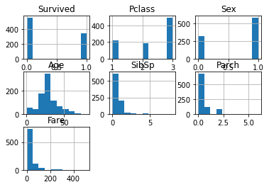

```python
train.hist()
```

# 10

```python
train['Fare']=(train['Fare']-train['Fare'].mean())/train['Fare'].std()
train['Parch']=(train['Parch']-train['Parch'].mean())/train['Parch'].std()
train['SibSp']=(train['SibSp']-train['SibSp'].mean())/train['SibSp'].std()
train['Age']=(train['Age']-train['Age'].mean())/train['Age'].std()
train['Sex']=(train['Sex']-train['Sex'].mean())/train['Sex'].std()
train['Pclass']=(train['Pclass']-train['Pclass'].mean())/train['Pclass'].std()
```

```python
train
```

|  | Survived | Pclass | Sex | Age | SibSp | Parch | Fare | Embarked |
| --- | --- | --- | --- | --- | --- | --- | --- | --- |
| 0 | 0 | 0.826913 | 0.737281 | -0.581333 | 0.432550 | -0.473408 | -0.502163 | S |
| 1 | 1 | -1.565228 | -1.354813 | 0.648963 | 0.432550 | -0.473408 | 0.786404 | C |
| 2 | 1 | 0.826913 | -1.354813 | -0.273759 | -0.474279 | -0.473408 | -0.488580 | S |
| 3 | 1 | -1.565228 | -1.354813 | 0.418282 | 0.432550 | -0.473408 | 0.420494 | S |
| 4 | 0 | 0.826913 | 0.737281 | 0.418282 | -0.474279 | -0.473408 | -0.486064 | S |
| ... | ... | ... | ... | ... | ... | ... | ... | ... |
| 886 | 0 | -0.369158 | 0.737281 | -0.196865 | -0.474279 | -0.473408 | -0.386454 | S |
| 887 | 1 | -1.565228 | -1.354813 | -0.812013 | -0.474279 | -0.473408 | -0.044356 | S |
| 888 | 0 | 0.826913 | -1.354813 | -0.043078 | 0.432550 | 2.007806 | -0.176164 | S |
| 889 | 1 | -1.565228 | 0.737281 | -0.273759 | -0.474279 | -0.473408 | -0.044356 | C |
| 890 | 0 | 0.826913 | 0.737281 | 0.187602 | -0.474279 | -0.473408 | -0.492101 | Q |

891 rows × 8 columns

# 11

```python
train['Embarked']=train['Embarked'].astype('category').cat.codes
```

```python
train
```

|  | Survived | Pclass | Sex | Age | SibSp | Parch | Fare | Embarked |
| --- | --- | --- | --- | --- | --- | --- | --- | --- |
| 0 | 0 | 0.826913 | 0.737281 | -0.581333 | 0.432550 | -0.473408 | -0.502163 | 2 |
| 1 | 1 | -1.565228 | -1.354813 | 0.648963 | 0.432550 | -0.473408 | 0.786404 | 0 |
| 2 | 1 | 0.826913 | -1.354813 | -0.273759 | -0.474279 | -0.473408 | -0.488580 | 2 |
| 3 | 1 | -1.565228 | -1.354813 | 0.418282 | 0.432550 | -0.473408 | 0.420494 | 2 |
| 4 | 0 | 0.826913 | 0.737281 | 0.418282 | -0.474279 | -0.473408 | -0.486064 | 2 |
| ... | ... | ... | ... | ... | ... | ... | ... | ... |
| 886 | 0 | -0.369158 | 0.737281 | -0.196865 | -0.474279 | -0.473408 | -0.386454 | 2 |
| 887 | 1 | -1.565228 | -1.354813 | -0.812013 | -0.474279 | -0.473408 | -0.044356 | 2 |
| 888 | 0 | 0.826913 | -1.354813 | -0.043078 | 0.432550 | 2.007806 | -0.176164 | 2 |
| 889 | 1 | -1.565228 | 0.737281 | -0.273759 | -0.474279 | -0.473408 | -0.044356 | 0 |
| 890 | 0 | 0.826913 | 0.737281 | 0.187602 | -0.474279 | -0.473408 | -0.492101 | 1 |

891 rows × 8 columns

```python
survived=train[train['Survived']==1]
unsurvived=train[train['Survived']==0]
```

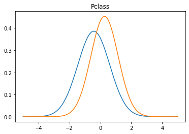

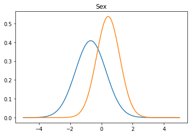

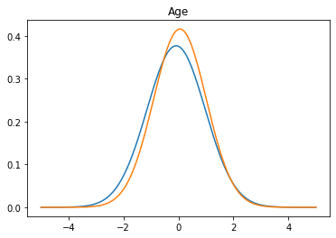

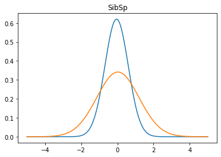

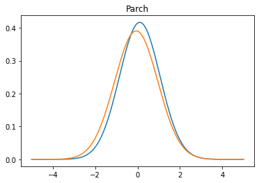

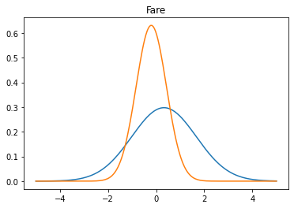

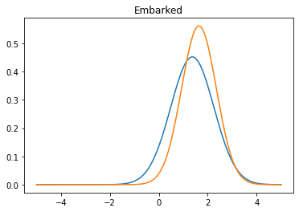

```python
col = ['Pclass','Sex','Age','SibSp','Parch','Fare','Embarked']
for i in col :
    s1=survived[i].mean()
    s2=survived[i].std()
    x=np.linspace(-5,5,200)
    y=norm.pdf(x,s1,s2)
    plt.plot(x,y)
    s3=unsurvived[i].mean()
    s4=unsurvived[i].std()
    x=np.linspace(-5,5,200)
    y2=norm.pdf(x,s3,s4)
    plt.plot(x,y2)
    plt.title(i)
    plt.show()
```

# 12

```python
test=pd.read_csv('test.csv')
```

```python
test
```

|  | PassengerId | Pclass | Name | Sex | Age | SibSp | Parch | Ticket | Fare | Cabin | Embarked |
| --- | --- | --- | --- | --- | --- | --- | --- | --- | --- | --- | --- |
| 0 | 892 | 3 | Kelly, Mr. James | male | 34.5 | 0 | 0 | 330911 | 7.8292 | NaN | Q |
| 1 | 893 | 3 | Wilkes, Mrs. James (Ellen Needs) | female | 47.0 | 1 | 0 | 363272 | 7.0000 | NaN | S |
| 2 | 894 | 2 | Myles, Mr. Thomas Francis | male | 62.0 | 0 | 0 | 240276 | 9.6875 | NaN | Q |
| 3 | 895 | 3 | Wirz, Mr. Albert | male | 27.0 | 0 | 0 | 315154 | 8.6625 | NaN | S |
| 4 | 896 | 3 | Hirvonen, Mrs. Alexander (Helga E Lindqvist) | female | 22.0 | 1 | 1 | 3101298 | 12.2875 | NaN | S |
| ... | ... | ... | ... | ... | ... | ... | ... | ... | ... | ... | ... |
| 413 | 1305 | 3 | Spector, Mr. Woolf | male | NaN | 0 | 0 | A.5. 3236 | 8.0500 | NaN | S |
| 414 | 1306 | 1 | Oliva y Ocana, Dona. Fermina | female | 39.0 | 0 | 0 | PC 17758 | 108.9000 | C105 | C |
| 415 | 1307 | 3 | Saether, Mr. Simon Sivertsen | male | 38.5 | 0 | 0 | SOTON/O.Q. 3101262 | 7.2500 | NaN | S |
| 416 | 1308 | 3 | Ware, Mr. Frederick | male | NaN | 0 | 0 | 359309 | 8.0500 | NaN | S |
| 417 | 1309 | 3 | Peter, Master. Michael J | male | NaN | 1 | 1 | 2668 | 22.3583 | NaN | C |

418 rows × 11 columns

```python
pclass_surv_mean=survived['Pclass'].mean()
pclass_surv_std=survived['Pclass'].std()
pclass_unsurv_mean=unsurvived['Pclass'].mean()
pclass_unsurv_std=unsurvived['Pclass'].std()
x=np.linspace(-5,5,200)
y1=norm.pdf(x,pclass_surv_mean,pclass_surv_std)
y2=norm.pdf(x,pclass_unsurv_mean,pclass_unsurv_std)
a=y2-y1
a[:50]=1
a[150:]=1
np.argmin(abs(a))
threshold=x[np.argmin(abs(a))]
```

```python
test['Pclass']=(test['Pclass']-test['Pclass'].mean())/test['Pclass'].std() #Normalization Pclass column
```

```python
test['Survived']=test['Pclass']<threshold
```

```python
test['Survived']=pd.get_dummies(test['Survived'],drop_first=True)
```

```python
test.to_csv('test_corrected.csv')
```

```python
pd.read_csv('test_corrected.csv')
```

|  | Unnamed: 0 | PassengerId | Pclass | Name | Sex | Age | SibSp | Parch | Ticket | Fare | Cabin | Embarked | Survived |
| --- | --- | --- | --- | --- | --- | --- | --- | --- | --- | --- | --- | --- | --- |
| 0 | 0 | 892 | 0.872436 | Kelly, Mr. James | male | 34.5 | 0 | 0 | 330911 | 7.8292 | NaN | Q | 0 |
| 1 | 1 | 893 | 0.872436 | Wilkes, Mrs. James (Ellen Needs) | female | 47.0 | 1 | 0 | 363272 | 7.0000 | NaN | S | 0 |
| 2 | 2 | 894 | -0.315441 | Myles, Mr. Thomas Francis | male | 62.0 | 0 | 0 | 240276 | 9.6875 | NaN | Q | 1 |
| 3 | 3 | 895 | 0.872436 | Wirz, Mr. Albert | male | 27.0 | 0 | 0 | 315154 | 8.6625 | NaN | S | 0 |
| 4 | 4 | 896 | 0.872436 | Hirvonen, Mrs. Alexander (Helga E Lindqvist) | female | 22.0 | 1 | 1 | 3101298 | 12.2875 | NaN | S | 0 |
| ... | ... | ... | ... | ... | ... | ... | ... | ... | ... | ... | ... | ... | ... |
| 413 | 413 | 1305 | 0.872436 | Spector, Mr. Woolf | male | NaN | 0 | 0 | A.5. 3236 | 8.0500 | NaN | S | 0 |
| 414 | 414 | 1306 | -1.503319 | Oliva y Ocana, Dona. Fermina | female | 39.0 | 0 | 0 | PC 17758 | 108.9000 | C105 | C | 1 |
| 415 | 415 | 1307 | 0.872436 | Saether, Mr. Simon Sivertsen | male | 38.5 | 0 | 0 | SOTON/O.Q. 3101262 | 7.2500 | NaN | S | 0 |
| 416 | 416 | 1308 | 0.872436 | Ware, Mr. Frederick | male | NaN | 0 | 0 | 359309 | 8.0500 | NaN | S | 0 |
| 417 | 417 | 1309 | 0.872436 | Peter, Master. Michael J | male | NaN | 1 | 1 | 2668 | 22.3583 | NaN | C | 0 |

418 rows × 13 columns